# UZH STA426 Week 13: Full scRNAseq pipeline

## General workflow

1. (Reading data)
2. QC and filtering
3. Normalization
4. Dimensionality reduction
5. Clustering and cluster annotation
6. (Integration)
7. Differential expression analysis

## General R-based pipelines

2 very documented frameworks / pipelines

- [Orchestrating Single-Cell Analysis](https://bioconductor.org/books/release/OSCA/)
- [Seurat](https://satijalab.org/seurat/)

## Reading data

```r
 dirs <- list.dirs("path/to/cellranger_results", full.names=TRUE)
 names(dirs) <- basename(fastq_dirs)
 sce <- DropletUtils::read10xCounts(dirs)
```

To read data from `alevin`, see the *tximport* package

To read data from a python AnnData object:

```r
sce <- anndataR::read_h5ad("file.h5ad", as="SingleCellExperiment")
```

## The SingleCellExperiment (SCE) class

Based on the *SummarziedExperiment* class:

[figure not shown]

## The SingleCellExperiment (SCE) class

- Single `colData` columns (cell properties) can be accessed through the `$`, or as a whole through `colData(sce)`.
- `rowData` for feature-level data
- `assays(sce)` produces a list of assays; the SCE class also includes the `counts(sce)` (equivalent to `assays(sce)$counts`) and `logcounts(sce)` accessors for specific assays.
- In addition, the SCE can hold information about low-dimensional representations, accessible as named list through `reducedDims(sce)`
- Both classes are compatible with the interactive SE explorer *iSEE* !

… more about *[SingleCellExperiment](https://bioconductor.org/packages/3.22/SingleCellExperiment/vignettes/intro)*

## QC and filtering

- The *scater* package is a handy tool for quality control and plotting, working with the SCE class.
- In BioC <3.10, per-cell and per-gene statistics used to be compiled with `calculateQCMetrics()`
- In `devel` (>=3.10), has been replaced with `addQCPerCell()` and `addQCPerFeature()`
- `isOutlier()` can be used to determine cells whose given property is outside a given range from the median
- Warning: Too stringent filters can be heavily biased against some cell types ([e.g. here](https://genomebiology.biomedcentral.com/articles/10.1186/s13059-020-02136-7/figures/3)) !

## Doublets

- when >=2 cells get captured in the same droplet/well and are sequenced with a single cellular barcode
- Doublets created from the same ‘type’, termed *homotypic doublets*, are extremely difficult to detect in RNA data
- Methods concentrate on *neotypic* or *heterotypic doublets* doublets, which combine cells of different types, are the most problematic

## Ambiant RNA contamination

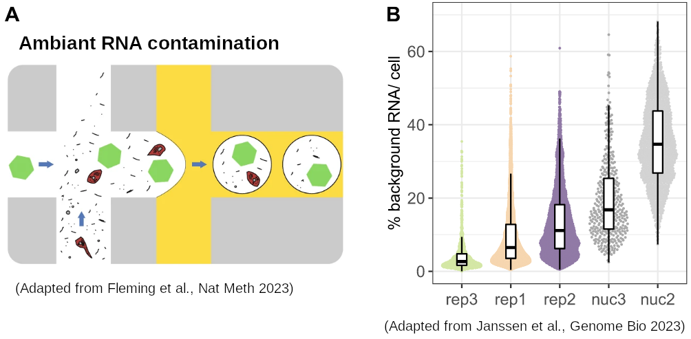

- The best method to get rid of it is CellBender
- however it effectively requires a GPU
- (as a CPU alternative, see [DecontX](https://bioconductor.org/packages/decontX)

## Cell cycle

- When present, needs to be correctly *identified*, then can be interpreted or regressed out
- [tricycle](https://bioconductor.org/packages/release/bioc/vignettes/tricycle/inst/doc/tricycle.html) is what works best in our hands

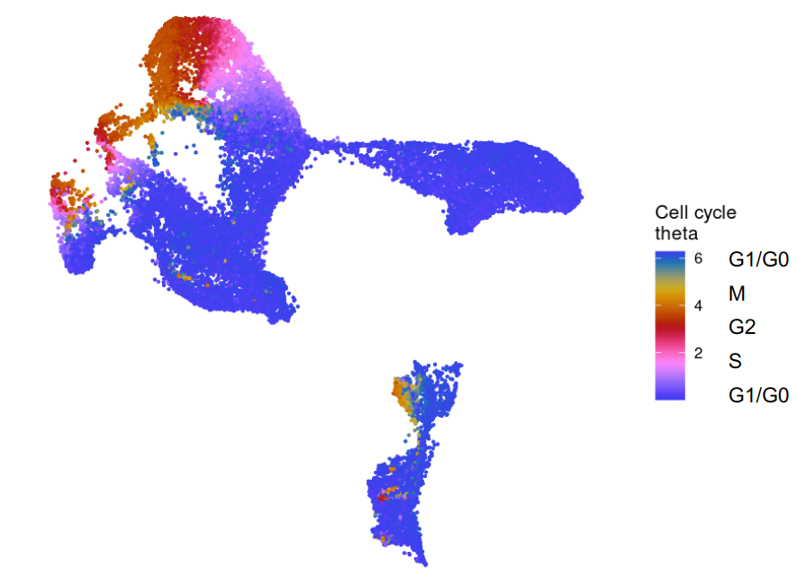

## Browsing clustering resolutions

[figure not shown]

See the clustree package

## Cluster annotation

- One can use a combination of:
  - relying on known markers
  - look for genes with cluster-specific expression patterns (see for instance `scran::findMarkers`)
- In addition, a variety of methods are being developed to recognize cell types from reference data (e.g. from [OSCA](https://bioconductor.org/books/3.22/OSCA.basic/cell-type-annotation.html#assigning-cell-labels-from-reference-data), or [scClassify](https://www.bioconductor.org/packages/release/bioc/html/scClassify.html))

## Handling data out-of-memory

If this had been a very large dataset, having the entire thing in memory might not be practical. However it’s possible to have the assays of the SingleCellExperiment on disk. See the *HDF5Array* package:

```r
# saving a SCE with assays in h5 format:
HDF5Array::saveHDF5SummarizedExperiment(sce, prefix="ondisk_")
# this loads the SCE object in memory except the assays:
sce2 <- HDF5Array::loadHDF5SummarizedExperiment(prefix="ondisk_")
# when accessing the data for a gene, this bit of data is read on the fly :
counts(sce2)["gene1",]
```